# 1. blockCV introduction: how to create block cross-validation folds

## Visualising the folds

You can visualise the generate folds for all block cross-validation strategies. You can optionally add a raster layer for background maps using `r` option. When `r` is supplied the plots might be slightly slower.

Let’s plot spatial clustering folds created in previous section (using `cv_cluster`):

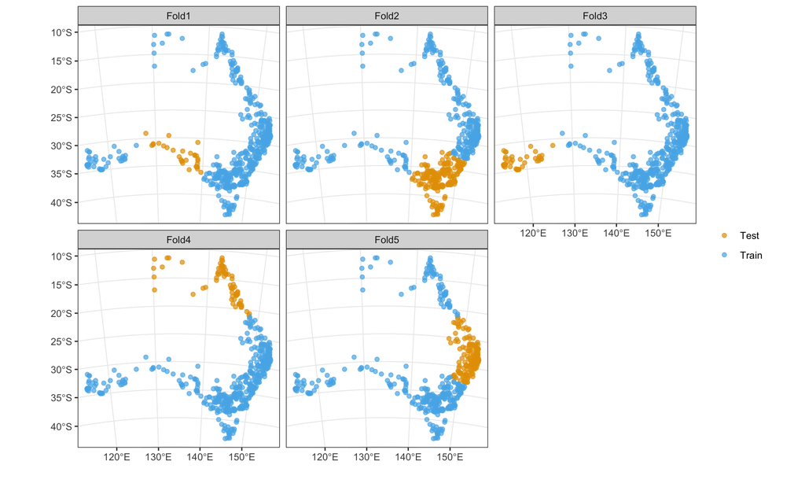

```r
cv_plot(cv = scv,
        x = pa_data)
```

When `cv_buffer` is used for plotting, only first 10 folds are shown. You can choose any set of CV folds for plotting. If `remove_na = FALSE` (default is `TRUE`), the `NA` in legend shows the excluded points.

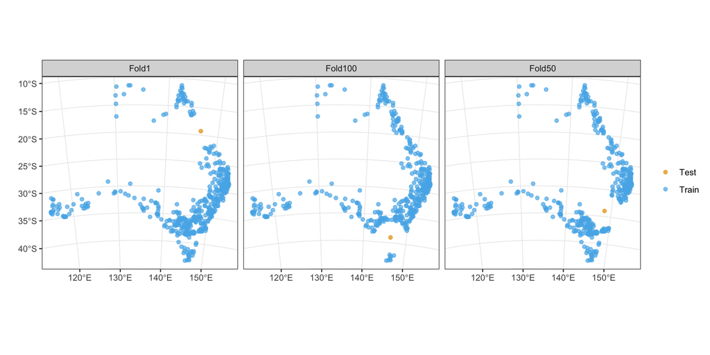

```r
cv_plot(cv = bloo,
        x = pa_data,
        num_plots = c(1, 50, 100))
```

If you do not supply `x` when plotting a `cv_spatial` object, only the spatial blocks are plotted.

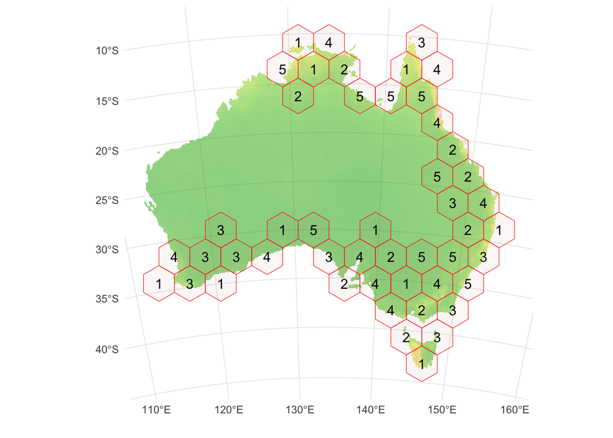

```r
cv_plot(cv = sb1,
        r = rasters,
        raster_colors = terrain.colors(10, alpha = 0.5),
        label_size = 4)
```

## Check similarity

The `cv_similarity` function can check for environmental similarity between the training and testing folds and thus possible extrapolation. It computes multivariate environmental similarity surface (MESS) as described in Elith et al. (2010). MESS represents how similar a point in a testing fold is to a training fold (as a reference set of points), with respect to a set of predictor variables in `r`. The negative values are the sites where at least one variable has a value that is outside the range of environments over the reference set, so these are novel environments.

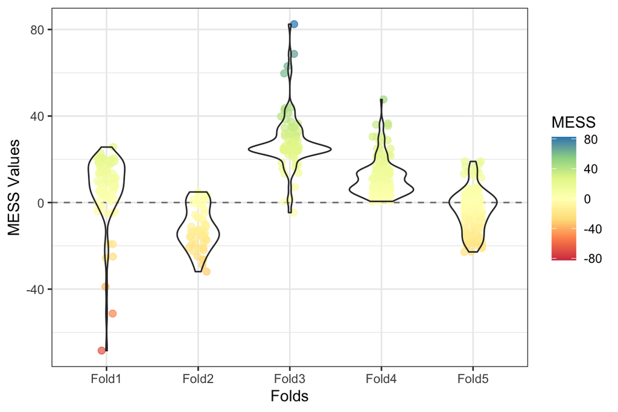

```r
cv_similarity(cv = ecv, # the environmental clustering
              x = pa_data,
              r = rasters,
              progress = FALSE)
```

## Estimating size: the effective range of spatial autocorrelation

To support a first choice of block size, prior to any model fitting, package `blockCV` includes the option for the user to look at the existing autocorrelation in the response or predictors (as an indication of landscape spatial structure). This tool does not suggest any absolute solution to the problem, but serves as a guide to the user. It provides information about *the effective range of spatial autocorrelation* which is the range over which observations are independent.

When only `r` is supplied, the `cv_spatial_autocor` function works by automatically fitting variograms to each continuous raster and finding the effective range of spatial autocorrelation. Variogram is a fundamental geostatistical tool for measuring spatial autocorrelation (O’Sullivan and Unwin, 2010).

```r
sac1 <- cv_spatial_autocor(r = rasters,
                           num_sample = 5000)
```

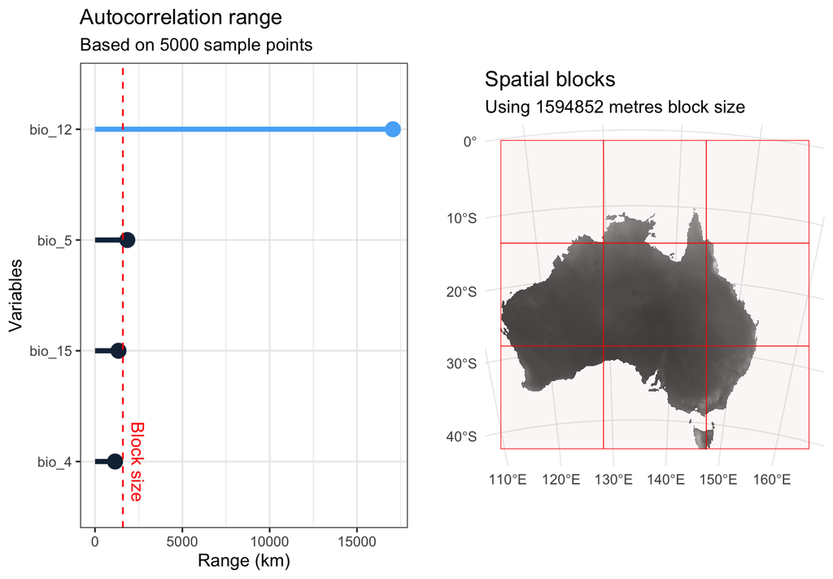

The plotted block size is based on the *median* of the spatial autocorrelation ranges. This could be as the **minimum block size** for creating spatially separated folds. Variograms are computed taking a number of random points (`5000` as default) from each input raster file. The variogram fitting procedure is done using [**automap**](https://CRAN.R-project.org/package=automap) package (Hiemstra et al., 2009), using the isotropic variogram and assuming the data meets the geostatistical criteria e.g. stationarity.

The output object of this function is an `cv_spatial_autocor` object, an object of class S3.

```r
# class of the output result
class(sac1)
```

```
## [1] "cv_spatial_autocor"
```

```r
# summary statistics of the output
summary(sac1)
```

```
## Summary statistics of spatial autocorrelation ranges of all input layers:
## Length  Class   Mode
##      0   NULL   NULL
## NULL
```

Alternatively, only use the response data using `x` and `column`. This could be a binary or continuous variable provided in as a column in the sample points `sf` object. This could be the response or the residuals of a fitted model.

```r
sac2 <- cv_spatial_autocor(x = pa_data,
                           column =  "occ")
```

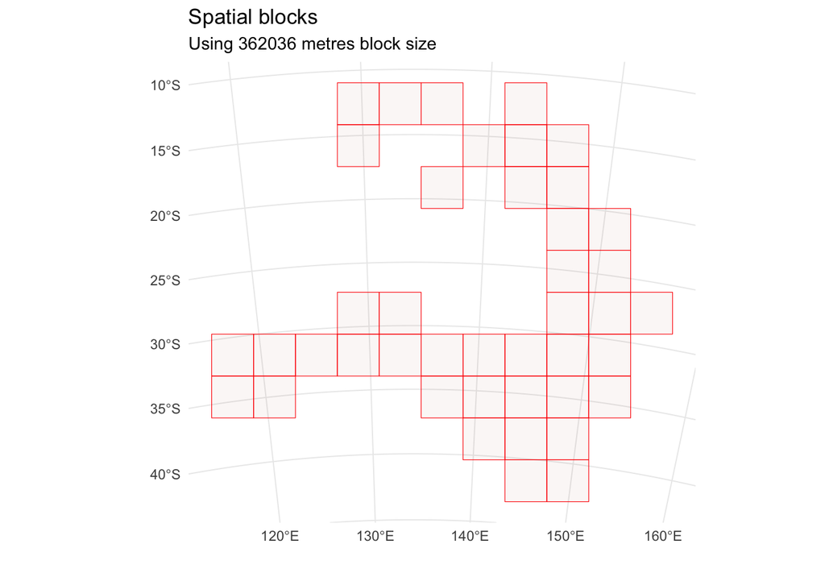

To visualise them (this needs the `automap` package to be loaded):

```r
library(automap)
```

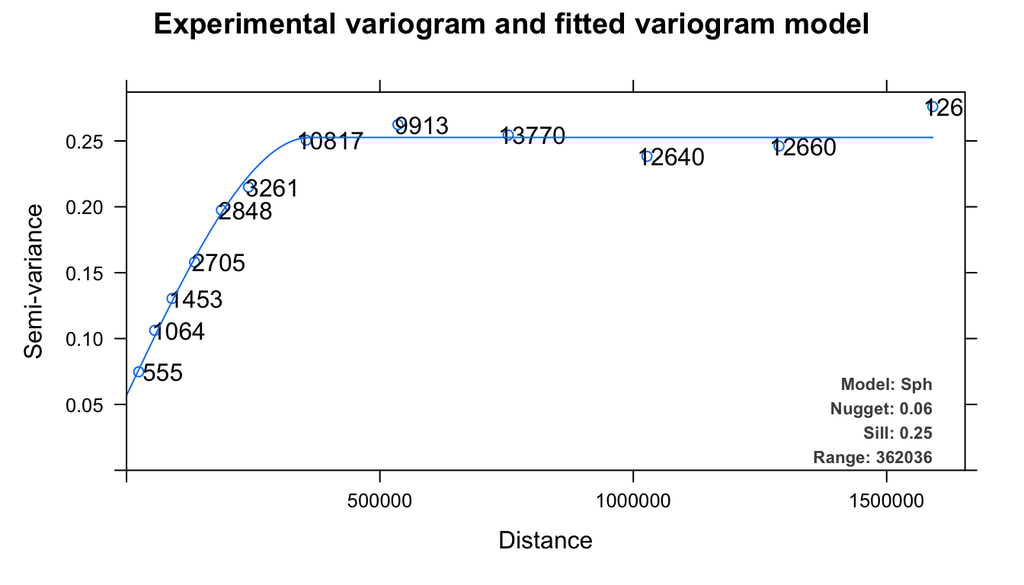

```r
plot(sac2$variograms[[1]])
```

Package `blockCV` also provides a visualisation tool for assisting in block size selection. This tool is developed as local web applications using R package `shiny`. With `cv_block_size`, the user can choose among block sizes in a specified range, visualise the resulting blocks interactively, viewing the impact of block size on number and arrangement of blocks in the landscape (and optionally on the distribution of sample points in those blocks).

Using only raster data:

```r
cv_block_size(r = rasters)
```

Or use only spatial sample data:

```r
cv_block_size(x = pa_data,
              column = "occ") # optionally add the response
```

Or add both raster and samples (also define a min/max size):

```r
cv_block_size(x = pa_data,
              column = "occ",
              r = rasters,
              min_size = 2e5,
              max_size = 9e5)
```

Note that the interactive plots cannot be shown here, as they require opening an external window or web browser. When using `cv_block_size`, slide to the selected block size, and click **Apply Changes** to change the block size.

## References:

- Hiemstra, P. H., Pebesma, E. J., Twenhöfel, C. J., & Heuvelink, G. B. (2009). Real-time automatic interpolation of ambient gamma dose rates from the Dutch radioactivity monitoring network. Computers & Geosciences, 35(8), 1711–1721.
- O’Sullivan, D., & Unwin, D. J. (2010). Geographic Information Analysis (2nd ed.). John Wiley & Sons.
- C. Milà, J. Mateu, E. Pebesma, and H. Meyer, Nearest Neighbour Distance Matching Leave-One-Out Cross-Validation for map validation, Methods in Ecology and Evolution (2022).
- Valavi R, Elith J, Lahoz-Monfort JJ, Guillera-Arroita G. **blockCV: An R package for generating spatially or environmentally separated folds for k-fold cross-validation of species distribution models**. *Methods Ecol Evol.* 2019; 10:225–232. [doi: 10.1111/2041-210X.13107](https://doi.org/10.1111/2041-210X.13107)